# The Impact of Severe Weather Events to Public Health and Economic Problems for Communities and Municipalities

# Synopsis

By analyzing the NOAA data, we found:  
1. Across the United States, “Tornado” is most harmful with respect to population health;  
2. Across the United States, “Storm Surge”, “Hurricane Typhoon” and “Tornado” have the greatest economic consequences.

# Introduction

*The text in this document are partially from Reproducible Research [Peer Assessment 2](https://class.coursera.org/repdata-015/human_grading/view/courses/973516/assessments/4/submissions) to help the peer assessment.*

“Storms and other severe weather events can cause both public health and economic problems for communities and municipalities. Many severe events can result in fatalities, injuries, and property damage, and preventing such outcomes to the extent possible is a key concern.

This project involves exploring the U.S. National Oceanic and Atmospheric Administration’s (NOAA) storm database. This database tracks characteristics of major storms and weather events in the United States, including when and where they occur, as well as estimates of any fatalities, injuries, and property damage."

In particular, this project is trying to answer the following two questions.  
1. Across the United States, which types of events (as indicated in the EVTYPE variable) are most harmful with respect to population health?  
2. Across the United States, which types of events have the greatest economic consequences?

# Data Processing

The data ([Storm Data](https://d396qusza40orc.cloudfront.net/repdata%2Fdata%2FStormData.csv.bz2) [47Mb]) come in the form of a comma-separated-value file compressed via the bzip2 algorithm to reduce its size.

National Weather Service [Storm Data Documentation](https://d396qusza40orc.cloudfront.net/repdata%2Fpeer2_doc%2Fpd01016005curr.pdf) and National Climatic Data Center Storm Events [FAQ](https://d396qusza40orc.cloudfront.net/repdata%2Fpeer2_doc%2FNCDC%20Storm%20Events-FAQ%20Page.pdf) are some documentation of the database available.

The events in the database start in the year 1950 and end in November 2011. In the earlier years of the database there are generally fewer events recorded, most likely due to a lack of good records. More recent years should be considered more complete.

```r
# Load the libraries
suppressPackageStartupMessages(library(dplyr))
suppressPackageStartupMessages(library(data.table))
suppressPackageStartupMessages(library(ggplot2))
```

```r
# Download the file if it does not exist
if (!file.exists("repdata-data-StormData.csv")) {
  if (!file.exists("repdata-data-StormData.csv.bz2")) {
    url="https://d396qusza40orc.cloudfront.net/repdata%2Fdata%2FStormData.csv.bz2"
    download.file(url, destfile="repdata-data-StormData.csv.bz2", method="curl")
    dateDownloaded <- date()
  } else {
    unzip("repdata-data-StormData.csv.bz2")
  }
}
```

Let’s load and subset the data.

```r
# Load the csv data file
df <- read.csv("repdata-data-StormData.csv", na.strings = c("", " ", "NA", "NaN"), stringsAsFactors = FALSE)
columns <- c("BGN_DATE", "STATE", "EVTYPE", "FATALITIES", "INJURIES", "PROPDMG", "PROPDMGEXP", "CROPDMG", "CROPDMGEXP")
df_subset  <- df[columns]
```

## Tidy the data.

1. Remove non-US territory.

```r
st <- c(state.abb, "DC")
df_subset_0  <- df_subset[df_subset$STATE %in% st,]
```

2. Remove the data contains “Summary …” in “EVTYPE” column.

```r
df_subset_0  <- df_subset_0[!grepl("Summary",df_subset$EVTYPE),]
```

3. Select the data when there is either death, injuries, property damage, or crop damage.

```r
df_subset_0  <- subset(df_subset_0, FATALITIES>0 | INJURIES>0 | PROPDMG>0 | CROPDMG>0)
```

4. Remove the EVTYPE marked as “?”.

```r
df_subset_0<- df_subset_0[!grepl("\\?",df_subset_0$EVTYPE),]
```

5. Trim the “EVTYPE” by, for example, removing the leading or trailing white space, and keep single space if there are multiple ones. Replace “/” by " “, etc.

```r
df_subset_0$EVTYPE <- toupper(df_subset_0$EVTYPE)
df_subset_0$EVTYPE <- gsub("\\/"        , " ", df_subset_0$EVTYPE)
df_subset_0$EVTYPE <- gsub("\\&|-"      , "" , df_subset_0$EVTYPE)
df_subset_0$EVTYPE <- gsub("^\\s+|\\s+$", "" , df_subset_0$EVTYPE)
df_subset_0$EVTYPE <- gsub("\\s+"       , " ", df_subset_0$EVTYPE)
df_subset_0$EVTYPE <- gsub(","          , "" , df_subset_0$EVTYPE)
df_subset_0$EVTYPE <- gsub("\\(|\\)"    , "" , df_subset_0$EVTYPE)
df_subset_0$EVTYPE <- gsub("\\\\"       , " ", df_subset_0$EVTYPE)
df_subset_0$EVTYPE <- gsub("WINDS"      , "WIND", df_subset_0$EVTYPE)
df_subset_0$EVTYPE <- gsub("STORMS"     , "STORM", df_subset_0$EVTYPE)
df_subset_0$EVTYPE <- gsub("FIRES"      , "FIRE", df_subset_0$EVTYPE)
df_subset_0$EVTYPE <- gsub("WILDFIRE"   , "WILD FIRE", df_subset_0$EVTYPE)
df_subset_0$EVTYPE <- gsub("TORNADOES"  , "TORNADO", df_subset_0$EVTYPE)
df_subset_0$EVTYPE <- gsub("SQUALLS"    , "SQUALL", df_subset_0$EVTYPE)
df_subset_0$EVTYPE <- gsub("WINDCHILL"  , "WIND CHILL", df_subset_0$EVTYPE)
df_subset_0$EVTYPE <- gsub("AVALANCE"    ,"AVALANCHE",df_subset_0$EVTYPE)
df_subset_0$EVTYPE <- gsub("FLOODS|FLOODING", "FLOOD", df_subset_0$EVTYPE)
df_subset_0$EVTYPE <- gsub("WATERSPOUTTORNADO", "WATERSPOUT TORNADO", df_subset_0$EVTYPE)
df_subset_0$EVTYPE <- gsub("TSTM|THUDERSTORM|THUNDEERSTORM|THUNDERSNOW|THUNDERESTORM|TUNDERSTORM|THUNDERTORM|THUNERSTORM", "THUNDERSTORM", df_subset_0$EVTYPE)
df_subset_0$EVTYPE <- gsub("THUNDERSTORMWIND", "THUNDERSTORM WIND", df_subset_0$EVTYPE)
df_subset_0$EVTYPE <- gsub("THUNDERSTORMW", "THUNDERSTORM WIND",df_subset_0$EVTYPE)
df_subset_0$EVTYPE <- gsub("WINS|WINDS|WIND\\.", "WIND", df_subset_0$EVTYPE)
df_subset_0$EVTYPE <- gsub("FLOOD FLOOD","FLOOD",df_subset_0$EVTYPE)
df_subset_0$EVTYPE <- gsub("FLOOD FLASH","FLASH FLOOD",df_subset_0$EVTYPE)
df_subset_0$EVTYPE <- gsub("FLOODFLODD","FLOOD",df_subset_0$EVTYPE)
df_subset_0$EVTYPE <- gsub("WINTRY","WINTER",df_subset_0$EVTYPE)
df_subset_0$EVTYPE <- gsub("WINDHALL","WIND",df_subset_0$EVTYPE)
df_subset_0$EVTYPE <- gsub("FLOODS|FLOODING","FLOOD",df_subset_0$EVTYPE)
df_subset_0$EVTYPE <- gsub("LAKEEFFECT","LAKE EFFECT",df_subset_0$EVTYPE)
```

The dataset can be further aggregated to 48 categories according to the “NATIONAL WEATHER SERVICE INSTRUCTION”“, but for this assignment, the idea is more important.

Let’s sort/order the data regarding the death/injury. Let us first creat a new variable by combing the fatality and injury.

```r
df_subset_0$fatality_injury <- as.numeric(df_subset_0$FATALITIES) + as.numeric(df_subset_0$INJURIES)
df_subset_0$EVTYPE <- as.factor(df_subset_0$EVTYPE)
df_subset_1 <- group_by(df_subset_0, EVTYPE)
df_subset_2 <- summarize(df_subset_1, sum_fatality_injury=sum(fatality_injury))
```

# Results

```r
df_subset_2 <- df_subset_2[order(-df_subset_2$sum_fatality_injury),]
setnames(df_subset_2, names(df_subset_2),c("Weather_Event_Type", "Number_of_Fatality_and_Injury"))
```

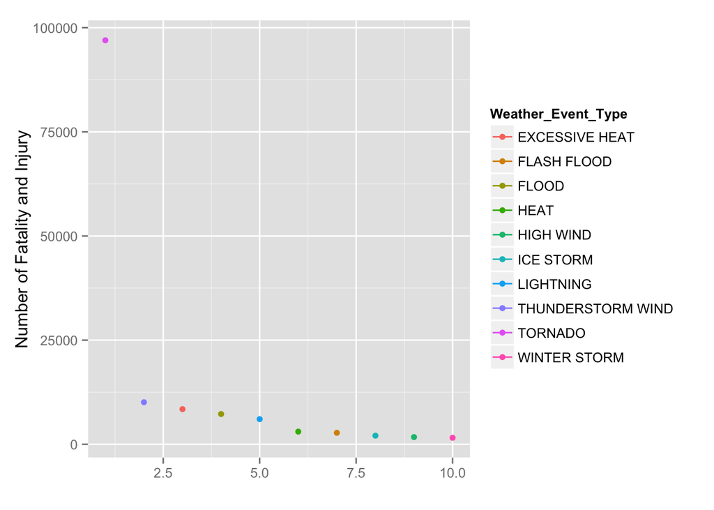

```r
df_num <- matrix(1:10,ncol=1,byrow=TRUE)
df_num <- as.data.frame(df_num)
df_subset_2 <- cbind(df_num, df_subset_2[1:10,])
g <- ggplot(df_subset_2, aes(x=V1, y=Number_of_Fatality_and_Injury, colour=Weather_Event_Type, group=Weather_Event_Type)) + geom_line() + geom_point() + labs(x="",y="Number of Fatality and Injury")
print (g)
```

In principle, we can combine “HEAT” and “EXCESSIVE HEAT” in one category, but I think what we have is good enough for this project.

The following will calculate the property and crop damagae.

```r
df_subset_0[is.na(df_subset_0)] <- 0
df_subset_0$PROPDMGEXP[df_subset_0$PROPDMGEXP %in% c('','-','?','+','0')] <- 1
df_subset_0$PROPDMGEXP[df_subset_0$PROPDMGEXP == '1'] <- 10
df_subset_0$PROPDMGEXP[df_subset_0$PROPDMGEXP %in% c('h','H','2')] <- 100
df_subset_0$PROPDMGEXP[df_subset_0$PROPDMGEXP %in% c('k','K','3')] <- 1000
df_subset_0$PROPDMGEXP[df_subset_0$PROPDMGEXP == '4'] <- 1e4
df_subset_0$PROPDMGEXP[df_subset_0$PROPDMGEXP == '5'] <- 1e5
df_subset_0$PROPDMGEXP[df_subset_0$PROPDMGEXP %in% c('m','M','6')] <- 1e6
df_subset_0$PROPDMGEXP[df_subset_0$PROPDMGEXP == '7'] <- 1e7
df_subset_0$PROPDMGEXP[df_subset_0$PROPDMGEXP == '8'] <- 1e8
df_subset_0$PROPDMGEXP[df_subset_0$PROPDMGEXP == 'B'] <- 1e9
df_subset_0$PROPDMGEXP <- as.numeric(df_subset_0$PROPDMGEXP)
df_subset_0$CROPDMGEXP <- as.numeric(df_subset_0$CROPDMGEXP)
df_subset_0$Total_Damage <- df_subset_0$PROPDMG*df_subset_0$PROPDMGEXP/1e9 + df_subset_0$CROPDMG*df_subset_0$CROPDMGEXP/1e9

df_subset_1 <- group_by(df_subset_0, EVTYPE)
df_subset_2 <- summarize(df_subset_1, Sum_Total_Damage=sum(Total_Damage,na.rm=TRUE))
df_subset_2 <- df_subset_2[order(-df_subset_2$Sum_Total_Damage),]
setnames(df_subset_2, names(df_subset_2),c("Weather_Event_Type", "Total_Damage"))
```

**The following table and figure shows that “Storm Surge”, “Hurricane Typhoon” and “Tornado” are most harmful with respect to economic consequences.**

```r
df_subset_2 <- cbind(df_num, df_subset_2[1:10,])
df_subset_2[1:10,]
```

```
##    V1 Weather_Event_Type Total_Damage
## 1   1        STORM SURGE    43.320621
## 2   2  HURRICANE TYPHOON    42.340545
## 3   3            TORNADO    40.780270
## 4   4              FLOOD    11.854652
## 5   5        FLASH FLOOD     9.698814
## 6   6               HAIL     7.740481
## 7   7     TROPICAL STORM     6.621829
## 8   8       WINTER STORM     5.670653
## 9   9  THUNDERSTORM WIND     5.568297
## 10 10          HIGH WIND     3.360206
```

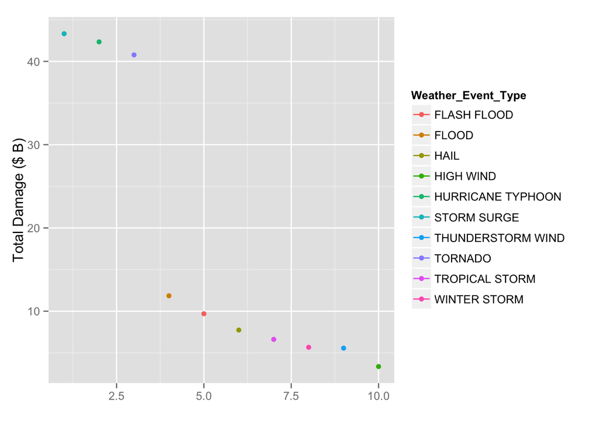

```r
g <- ggplot(df_subset_2, aes(x=V1, y=Total_Damage, colour=Weather_Event_Type, group=Weather_Event_Type)) + geom_line() + geom_point() + labs(x="",y="Total Damage ($ B)")
print (g)
```

# Conclusions

By analyzing the NOAA data, we found the following conclusions:  
1. Across the United States, Tornado is most harmful with respect to population health. 2. Across the United States, “Storm Surge”, “Hurricane Typhoon” and “Tornado” have the greatest economic consequences.